# gauthier_Assignment_3

## OnMart Superstore

**Author:** Atef Bader, PhD

**Revised By:** Edward Arroyo, PhD

## Deliverables:

You are required to submit two files with the naming convention **LastName_Assignment_3** :

1. **IPYNB Script**: This is your original notebook file ( **LastName_Assignment_3.ipynb** ).
2. **HTML Document**: This file must include all the source code you have written along with its output. This should include your source code and output. Follow these steps to generate the HTML file:
   - After completing your work in the Jupyter Notebook, go to the menu bar at the top.
   - Click on File, then hover over Download as.
   - Select HTML (.html)
   - Save the file with the appropriate naming convention ( **LastName_Assignment_3.html** ).
   - **Ensure all code and outputs are properly displayed in the HTML document.**
3. **MP4 Video Recording:** A live demo recording lasting between 5 and 10 minutes.

**Note**: You are required to provide your code and its output immediately following each requirement for this assignment.

## High Level Description:

The OnMart superstore, mirroring the business models of Amazon, Walmart, and Target, operates as an online retailer. It features a variety of departments, each catering to different product categories such as Electronics, Clothing, Grocery, Furniture, Sports, and more.

## Logistics and Supply Chain Network of OnMart:

OnMart's supply chain encompasses numerous warehouses and distribution centers. Each warehouse caters to several distribution centers, which in turn deliver packages to various zip codes.

The key features of OnMart's logistics and supply chain network are as follows:

While OnMart operates numerous warehouses to support its distribution centers across different cities, not all cities have local warehouses. Specifically, Nashville and Atlanta lack warehouses. Presently, Nashville receives its supplies from warehouses in Chicago, whereas Atlanta's supplies are shipped from Miami warehouses. The following figure illustrates the structure of the OnMart delivery network:

[figure not shown]

For example, packages delivered to zip code 60651 by OnMart originate from Distribution Center 1. Both Distribution Center 1 and Distribution Center 2 receive their packages from Warehouse 1.

In addtion, Warehouse 1 is situated in zip code 60651, whereas Distribution Center 1 is located in zip code 60644.

The **logistics_supply_chain_network** table below provides a snapshot of delivery-related data for OnMart, including zip codes, corresponding cities in the state of Illinois. It details geographic coordinates and identifies specific warehouses and distribution centers that service these areas:

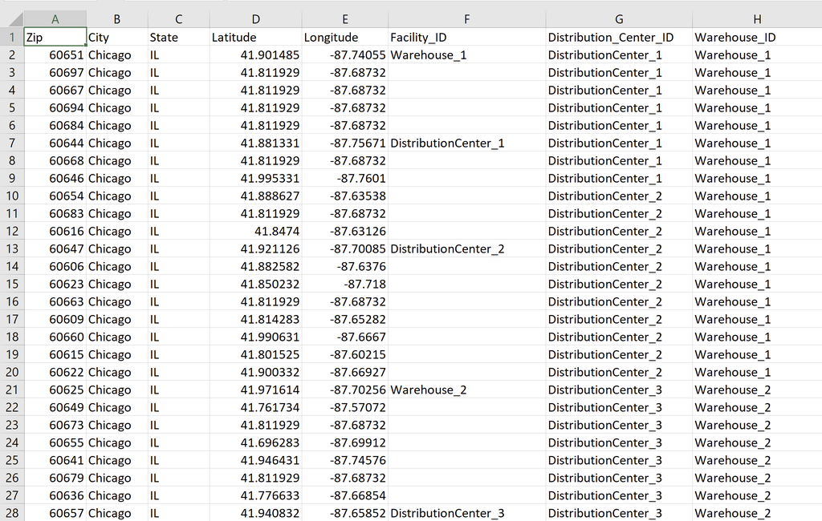

For example, packages delivered to zip code 60651 by OnMart originate from Distribution Center 1, which is located in zip code 60644. Both Distribution Center 1 and Distribution Center 2 are supplied by Warehouse 1, which is situated within zip code 60651.

# Departments and Products

OnMart has several departments that are selling products in different categories. The following is a sample of these departments and the different product categories they sell:

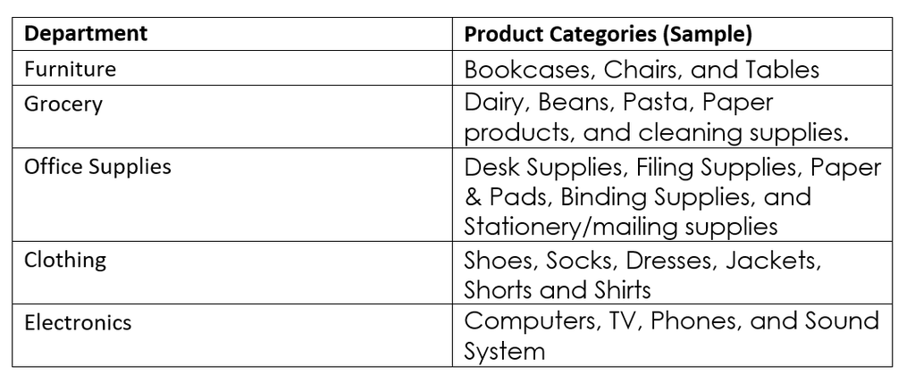

# Customers and Purchases

Customers can place orders online, selecting products from various categories across different departments. Each order is assigned a unique order number. During the ordering process, customers are required to provide their home address, a delivery address, and select a shipping class.

The following capabilities are available to customers:

- Purchasing items.
- Returning purchased items.
- Reviewing and rating purchased items.
- Sharing product descriptions of purchased items with friends on social networks.

**Connection Instructions**

- Connect Docker Hub and pull the Docker image: msds420/postgres-14.11-onmart
- Connect to the Docker Container msds420/postgres-14.11-onmart Postgres Server using the psycopg2 connection string (provided in the code below).
- Connect to the **OnMart** database (details provided in the code below).
- Utilize the two tables: **transactions_log** and **logistics_supply_chain_network** to answer all the requirements in this assignment.

### Install the 'psycopg2-binary' package:

```python
# Install the 'psycopg2-binary' package, which is required for PostgreSQL database interactions.
# Note: This cell only needs to be executed once.
# After successful installation, you can comment out this cell since it is no longer needed.
import sys
!{sys.executable} -m pip install psycopg2-binary
```

```
Downloading psycopg2_binary-2.9.12-cp313-cp313-macosx_11_0_arm64.whl (3.8 MB)
   ━━━━━━━━━━━━━━━━━━━━━━━━━━━━━━━━━━━━━━━━ 3.8/3.8 MB 3.4 MB/s eta 0:00:00a 0:00:01
```

### Import the libraries and modules we need:

```python
import pandas as pd
import numpy as np
import seaborn as sns
import matplotlib
import matplotlib.pyplot as plt
import psycopg2  # required to connect to the PostgreSQL database.
```

### Check versions:

```python
from platform import python_version
print('python version installed     :', python_version(),'    ,needed: 3.7.7 or higher')
print('matplotlib version installed :', matplotlib.__version__,'    ,needed: 3.2.2 or higher')
print('numpy version installed      :', np.__version__,'    ,needed: 1.19.5 or higher')
```

```
python version installed     : 3.13.5     ,needed: 3.7.7 or higher
matplotlib version installed : 3.10.0     ,needed: 3.2.2 or higher
numpy version installed      : 1.26.4     ,needed: 1.19.5 or higher
```

# Docker

### Docker 101 Tutorial

Before you start the download/installation of Docker Desktop, watch the **Docker Crash Course for Absolute Beginners** video below.

```python
from IPython.display import YouTubeVideo

YouTubeVideo('pg19Z8LL06w', width=600, height=350)
```

[video not shown]

## Install Docker Desktop from here: https://docs.docker.com/engine/install/

[figure not shown]

#### Please wait 5 minutes for the docker container to complete its startup before you proceed to subsequent steps

```python
!docker compose up -d
```

```
[+] Running 1/1
 ✔ Container onmart  Running                                               0.0s
```

## From the Docker Desktop under Images verify you see msds420/postgres-14.11-onmart as follows:

[figure not shown]

### Please wait 5 minutes before you execute the following cells.

### It takes the Docker Postgres-14 container roughly 3 minutes to finalize its startup

# Important Notes:

- In this assignment, you will be connecting to the Docker container/image PostgreSQL server, which already has the database and tables needed for this assignment.
- Please make sure you are connecting to the correct port number(5436) below with login=postgres and password=root.

```python
# Establish a connection to the PostgreSQL database
db_connection = psycopg2.connect(
    host='127.0.0.1',        # IP address of the Postgres database server
    port=5436,               # Port number for postgres docker container
    dbname="onmart_superstore",         # Name of the database to connect to
    user="postgres",         # Enter postgres for authentication
    password="root"
)


# Create a cursor object using the established connection
# The cursor is used to execute queries and fetch data from the database
cursor = db_connection.cursor()
```

```python
# Execute SQL query to retrieve column names from the 'transactions_log' table
cursor.execute("SELECT COLUMN_NAME FROM INFORMATION_SCHEMA.COLUMNS WHERE TABLE_NAME = 'transactions_log'")

# Fetch all the rows returned by the executed query
columns = cursor.fetchall()

# Display the fetched column names
columns
```

```
[('profit',),
 ('expecteddeliverydate',),
 ('actualdeliverydate',),
 ('purchasedate',),
 ('quantity',),
 ('price',),
 ('rating',),
 ('shippingcost',),
 ('discount',),
 ('sales',),
 ('homezipcode',),
 ('segment',),
 ('orderpriority',),
 ('orderreturned',),
 ('reviewid',),
 ('friends',),
 ('customerid',),
 ('sharedwith',),
 ('firstname',),
 ('lastname',),
 ('creditcardnumber',),
 ('orderid',),
 ('productid',),
 ('department',),
 ('category',),
 ('itempurchased',),
 ('deliveryzipcode',)]
```

```python
# Get 5 rows from the transactions_log table

# Execute the SQL query using the cursor object.
cursor.execute("SELECT * from transactions_log limit 5;")

# Fetch all the rows returned by the executed query.
rows=cursor.fetchall()

# Print the retrieved rows
for row in rows:
    print(row)
```

```
('438-41-0336', 'Camryn', 'Collins', 'xxxx-xxxx-xxxx-5349', '70fa8d0e-9af4-461a-80d4-e15e4a0221fb', datetime.date(2019, 11, 19), datetime.date(2019, 11, 23), datetime.date(2019, 11, 27), 'OFF-AP-6485-170', 'Office Supplies', 'Appliances', 'RFID Scanners', 2, 326.99, 25.29, 24.46, 654.81, 65.481, '90…
('272-43-1200', 'Kian', 'Cronin', 'xxxx-xxxx-xxxx-5326', 'f3814223-cbd7-41af-b4bd-c5fe4b920097', datetime.date(2020, 12, 9), datetime.date(2020, 12, 13), datetime.date(2020, 12, 17), 'CLO-SH-5447-076', 'Clothing', 'Shorts', 'Flying Machine Denim Shorts', 4, 11.8, 2.83, 1.67, 48.36, 3.3852, '33283', …
('667-64-3631', 'Harry', 'Hickle', 'xxxx-xxxx-xxxx-5014', '940c6892-6e1c-4b7b-82b8-195cfde04fee', datetime.date(2018, 10, 31), datetime.date(2018, 11, 4), datetime.date(2018, 11, 8), 'ELE-PH-9857-139', 'Electronics', 'Phones', 'Panasonic Cordless Phone', 2, 733.6, 9.49, 19.82, 1456.87, 233.0992, '60…
('320-10-6885', 'Adam', 'Nolan', 'xxxx-xxxx-xxxx-2072', 'b8973a38-4246-483c-b369-3806402a1bd7', datetime.date(2018, 11, 27), datetime.date(2018, 12, 1), datetime.date(2018, 12, 5), 'ELE-CO-5426-764', 'Electronics', 'Copiers', 'Zoho Wireless Scanner - Automatic', 3, 553.36, 24.63, 21.65, 1663.06, 299…
('440-17-2806', 'Pansy', 'Hilll', 'xxxx-xxxx-xxxx-1407', 'e84683f0-f6f0-4855-ad75-262060009feb', datetime.date(2018, 4, 11), datetime.date(2018, 4, 15), datetime.date(2018, 4, 19), 'CLO-SH-1287-520', 'Clothing', 'Shorts', 'LP Shorts With Pockets', 4, 19.92, 2.91, 1.84, 80.75, 4.0375, '90077', '90077…
```

```python
# Putting all together in a pandas data frame.

# Retrieve column names from the cursor.description attribute.
# The description attribute contains metadata about the columns returned by the query.
# Each column's metadata is a tuple, where the first element is the column name.
columns = [column[0] for column in cursor.description]

# Create a DataFrame using the fetched data and the column names.
# This DataFrame represents the transaction log.
# The 'rows' variable contains the data, and 'colnames' provides the column headers.
customers = pd.DataFrame(rows, columns=columns)

# Display the DataFrame
customers
```

|  | customerid | firstname | lastname | creditcardnumber | orderid | purchasedate | expecteddeliverydate | actualdeliverydate | productid | department | ... | profit | deliveryzipcode | homezipcode | segment | orderpriority | orderreturned | rating | reviewid | friends | sharedwith |
| --- | --- | --- | --- | --- | --- | --- | --- | --- | --- | --- | --- | --- | --- | --- | --- | --- | --- | --- | --- | --- | --- |
| 0 | 438-41-0336 | Camryn | Collins | xxxx-xxxx-xxxx-5349 | 70fa8d0e-9af4-461a-80d4-e15e4a0221fb | 2019-11-19 | 2019-11-23 | 2019-11-27 | OFF-AP-6485-170 | Office Supplies | ... | 65.4810 | 90048 | 90048 | Home Office | Critical | No | 5 |  |  |  |
| 1 | 272-43-1200 | Kian | Cronin | xxxx-xxxx-xxxx-5326 | f3814223-cbd7-41af-b4bd-c5fe4b920097 | 2020-12-09 | 2020-12-13 | 2020-12-17 | CLO-SH-5447-076 | Clothing | ... | 3.3852 | 33283 | 33283 | Corporate | Critical | No | -1 | 14223-cbd7 |  |  |
| 2 | 667-64-3631 | Harry | Hickle | xxxx-xxxx-xxxx-5014 | 940c6892-6e1c-4b7b-82b8-195cfde04fee | 2018-10-31 | 2018-11-04 | 2018-11-08 | ELE-PH-9857-139 | Electronics | ... | 233.0992 | 60612 | 60612 | Consumer | High | No | 5 |  |  |  |
| 3 | 320-10-6885 | Adam | Nolan | xxxx-xxxx-xxxx-2072 | b8973a38-4246-483c-b369-3806402a1bd7 | 2018-11-27 | 2018-12-01 | 2018-12-05 | ELE-CO-5426-764 | Electronics | ... | 299.3508 | 30390 | 30390 | Consumer | High | No | 3 |  |  |  |
| 4 | 440-17-2806 | Pansy | Hilll | xxxx-xxxx-xxxx-1407 | e84683f0-f6f0-4855-ad75-262060009feb | 2018-04-11 | 2018-04-15 | 2018-04-19 | CLO-SH-1287-520 | Clothing | ... | 4.0375 | 90077 | 90077 | Corporate | Critical | No | -1 |  |  |  |

5 rows × 27 columns

```python
# SQL query to select all records from the transactions_log table
# with a limit of 5000 records to avoid loading too much data at once.
query = '''
        SELECT *
        FROM transactions_log
        LIMIT 5000;
        '''

# Execute the SQL query using the cursor object.
cursor.execute(query)

# Fetch all the rows returned by the executed query.
data = cursor.fetchall()

# Retrieve column names
colnames = [desc[0] for desc in cursor.description]

# Create a DataFrame using the fetched data and the column names.
customers = pd.DataFrame(data, columns=colnames)

# Display basic information about the DataFrame, such as column data types,
# non-null values count, and memory usage.
customers.info()
```

```
<class 'pandas.core.frame.DataFrame'>
RangeIndex: 5000 entries, 0 to 4999
Data columns (total 27 columns):
 #   Column                Non-Null Count  Dtype
---  ------                --------------  -----
 0   customerid            5000 non-null   object
 1   firstname             5000 non-null   object
 2   lastname              5000 non-null   object
 3   creditcardnumber      5000 non-null   object
 4   orderid               5000 non-null   object
 5   purchasedate          5000 non-null   object
 6   expecteddeliverydate  5000 non-null   object
 7   actualdeliverydate    5000 non-null   object
 8   productid             5000 non-null   object
 9   department            5000 non-null   object
```

[output cut: 19 more lines]

```python
# Get the column names for table logistics_supply_chain_network

cursor.execute("SELECT COLUMN_NAME FROM INFORMATION_SCHEMA.COLUMNS WHERE TABLE_NAME = 'logistics_supply_chain_network'")




rows=cursor.fetchall()

rows
```

```
[('where_is',),
 ('latitude',),
 ('longitude',),
 ('warehouse_id',),
 ('zipcode',),
 ('facility_id',),
 ('distribution_center_id',),
 ('city',),
 ('state',)]
```

```python
# Display 5 rows from the table logistics_supply_chain_network

cursor.execute("SELECT * from logistics_supply_chain_network;")
data=cursor.fetchall()

# Retrieve column names
colnames = [desc[0] for desc in cursor.description]

# Create a DataFrame using the fetched data and the column names.
centers = pd.DataFrame(data, columns=colnames)

# Display the 5 rows.
centers.head()
```

|  | zipcode | city | state | latitude | longitude | facility_id | distribution_center_id | warehouse_id | where_is |
| --- | --- | --- | --- | --- | --- | --- | --- | --- | --- |
| 0 | 60651 | Chicago | IL | 41.901485 | -87.74055 | Warehouse_1 | DistributionCenter_1 | Warehouse_1 | 0101000020E6100000D36A48DC63F3444061C3D32B65EF... |
| 1 | 60697 | Chicago | IL | 41.811929 | -87.68732 |  | DistributionCenter_1 | Warehouse_1 | 0101000020E610000045D61A4AEDE74440C078060DFDEB... |
| 2 | 60667 | Chicago | IL | 41.811929 | -87.68732 |  | DistributionCenter_1 | Warehouse_1 | 0101000020E610000045D61A4AEDE74440C078060DFDEB... |
| 3 | 60694 | Chicago | IL | 41.811929 | -87.68732 |  | DistributionCenter_1 | Warehouse_1 | 0101000020E610000045D61A4AEDE74440C078060DFDEB... |
| 4 | 60684 | Chicago | IL | 41.811929 | -87.68732 |  | DistributionCenter_1 | Warehouse_1 | 0101000020E610000045D61A4AEDE74440C078060DFDEB... |

```python
# check out zips
centers['zipcode'].nunique()
```

```
785
```

```python
# check out the number of locations
centers['facility_id'].nunique()
centers['distribution_center_id'].nunique()
centers['warehouse_id'].nunique()
```

```
22
```

```python
# what states are there?
centers['state'].value_counts() # show the number of centers in each state
```

```
state
NY    166
TX    123
GA    111
CA    100
FL     96
IL     85
MA     54
TN     44
NJ      1
MI      1
NC      1
PA      1
IA      1
VA      1
Name: count, dtype: int64
```

## Requirements

- Write your code in the cell below each requirement.
- The ipynb and HTML documents you are submitting must include the source code and the output for the following requirements.

#### NOTE:

- A sale is when orderreturned = 'No'
- A return is when orderreturned = 'Yes'
- ( **Use SQL - Postgres** ) implies that the task must be accomplished solely through a SQL query, whereas ( **Use Python - SQL - Postgres** ) suggests that Python can be utilized to modify the SQL query result to fulfill the requirement.

```python
# If your transactions ever get "stuck":
# ...current transaction is aborted, commands ignored until end of transaction block...
# uncomment and excute the following line.
# db_connection.rollback()
```

### Requirement 1:

- To see the delivery zip code with the most returns, count the total number of order returns per delivery zip code. Show the **top five** zip codes with their count. **( Use SQL - Postgres )**

```python
import pandas as pd

sql = """
    SELECT deliveryzipcode, COUNT(orderreturned) AS total_returns
    FROM transactions_log
    GROUP BY deliveryzipcode
    ORDER BY total_returns DESC
    LIMIT 5;
"""

# Load directly into a DataFrame using your active psycopg2 connection ('conn')
df = pd.read_sql_query(sql, db_connection)

# Display the table
display(df)
```

|  | deliveryzipcode | total_returns |
| --- | --- | --- |
| 0 | 33159 | 4085 |
| 1 | 10259 | 4079 |
| 2 | 60660 | 4044 |
| 3 | 75353 | 4038 |
| 4 | 75303 | 4037 |

### Requirement 2:

- Count the total number of orders for every product category in every Delivery Zip Code. Sort output by category. **( Use SQL - Postgres )**

```python
import pandas as pd

sql = """
    SELECT deliveryzipcode, COUNT(orderid) AS total_orders, category
    FROM transactions_log
    GROUP BY deliveryzipcode, category
    ORDER BY total_orders;
"""

# Load directly into a DataFrame using your active psycopg2 connection ('conn')
df2 = pd.read_sql_query(sql, db_connection)

# Display the table
display(df2)
```

|  | deliveryzipcode | total_orders | category |
| --- | --- | --- | --- |
| 0 | 75270 | 113 | Phones |
| 1 | 33169 | 115 | Furnishings |
| 2 | 75355 | 117 | Pasta |
| 3 | 33127 | 119 | Chairs |
| 4 | 2133 | 122 | Phones |
| ... | ... | ... | ... |
| 16480 | 75392 | 372 | Shorts |
| 16481 | 33170 | 376 | Shorts |
| 16482 | 2115 | 376 | TShirt |
| 16483 | 75390 | 378 | Shorts |
| 16484 | 30363 | 392 | Shorts |

16485 rows × 3 columns

### Requirement 3:

Calculate the total sales for each delivery zip code using the **sales** column for your total sales value. **Note that returned orders should not be counted as sales**. Sort the results by total sales in descending order, rounding to the nearest cent. Display **only** the top ten results. **(Use SQL - PostgreSQL)**

```python
import pandas as pd

sql = """
    SELECT
    deliveryzipcode,
    SUM(sales) AS total_sales
FROM transactions_log
WHERE orderreturned = 'No'
GROUP BY deliveryzipcode
ORDER BY total_sales DESC
LIMIT 10;
"""

# Load directly into a DataFrame using your active psycopg2 connection ('conn')
df3 = pd.read_sql_query(sql, db_connection)

# Display the table
display(df3)
```

|  | deliveryzipcode | total_sales |
| --- | --- | --- |
| 0 | 75284 | 3297252.34 |
| 1 | 37237 | 3245992.89 |
| 2 | 75236 | 3242844.58 |
| 3 | 33172 | 3233460.04 |
| 4 | 33231 | 3232382.14 |
| 5 | 30332 | 3229446.38 |
| 6 | 31195 | 3228091.48 |
| 7 | 30343 | 3220700.04 |
| 8 | 10006 | 3217293.72 |
| 9 | 2104 | 3211367.73 |

### Requirement 4:

- **Part 1: (Use Python, SQL, and PostgreSQL)**
  - Use Seaborn to create a side-by-side BoxPlot chart for product categories.
  - The boxplots should display the total sales (sum) for each delivery zip code on the y-axis, categorized by product category on the x-axis. Make sure you include a meaningful title and labels for both axes. Also, make sure all product category names are legibile.
  - It is recommended to create a dataframe with delivery zip code, category, and sales, and use this dataframe to generate the boxplots.
- **Part 2:**
  - In a Markdown cell, provide insights derived from the Boxplots. Your insights should be specific to the data being considered.

[Seaborn Boxplot Documentation](https://seaborn.pydata.org/generated/seaborn.boxplot.html)

|  | deliveryzipcode | total_sales | category |
| --- | --- | --- | --- |
| 0 | 33231 | 1032119.42 | Hunting & Fishing |
| 1 | 30332 | 971073.13 | Hunting & Fishing |
| 2 | 23303 | 959250.49 | Hunting & Fishing |
| 3 | 2215 | 957464.02 | Hunting & Fishing |
| 4 | 33172 | 956665.03 | Hunting & Fishing |
| ... | ... | ... | ... |
| 16480 | 30387 | 1582.71 | Beans |
| 16481 | 75355 | 1564.55 | Pasta |
| 16482 | 10041 | 1558.74 | Beans |
| 16483 | 33180 | 1555.64 | Beans |
| 16484 | 90099 | 1548.98 | Beans |

16485 rows × 3 columns

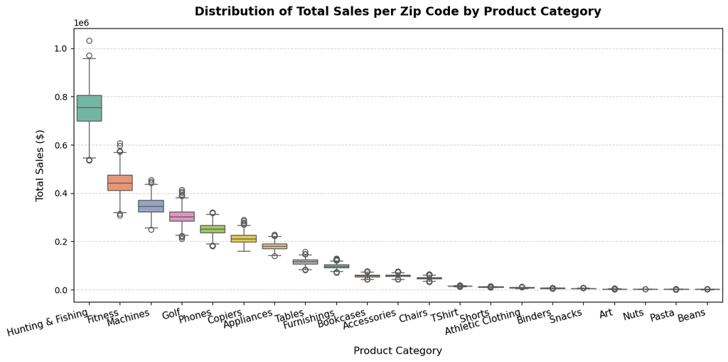

```python
import pandas as pd
import seaborn as sns
import matplotlib.pyplot as plt

sql = """
    SELECT
    deliveryzipcode,
    SUM(sales) AS total_sales,
    category
FROM transactions_log
WHERE orderreturned = 'No'
GROUP BY deliveryzipcode, category
ORDER BY total_sales DESC;
"""

# Load directly into a DataFrame using your active psycopg2 connection ('conn')
df4 = pd.read_sql_query(sql, db_connection)

# Display the table
display(df4)

# Create the Seaborn box plot
plt.figure(figsize=(12, 6))

ax = sns.boxplot(
    data=df4,
    x='category',
    y='total_sales',
    palette='Set2'
)

# 4. Custom Titles & Axis Labels
plt.title('Distribution of Total Sales per Zip Code by Product Category', fontsize=14, fontweight='bold', pad=15)
plt.xlabel('Product Category', fontsize=12, labelpad=10)
plt.ylabel('Total Sales ($)', fontsize=12, labelpad=10)

# 5. Ensure X-axis category labels are clean and legible
plt.xticks(rotation=15, ha='right', fontsize=11)

# Optional: Add gridlines for better readability
plt.grid(axis='y', linestyle='--', alpha=0.5)

# Adjust layout to prevent label clipping
plt.tight_layout()

# Display plot
plt.show()
```

**In the Markdown cell below, provide insights derived from the Boxplots.**

The products with the most sales have the highest range in total sales per zip code. Sporting equipiments and machines/technology have the most sales for OnMart. Food has the fewest sales along with clothing.

### Requirement 5:

- Calculate the total number of orders per product category per Home Zip Code per purchase month. Sort by home zip code, cateogry and month and show the first 12 records. **( Use Python - SQL - Postgres )**

You can use either Python or SQL to create the month field. If you want to try SQL, here is one of many sources of info: https://www.postgresqltutorial.com/postgresql-extract/

```python
import pandas as pd

sql = """
    SELECT
    homezipcode,
    COUNT(orderid) AS total_orders,
    category,
    DATE_PART('month', purchasedate::date) AS purchase_month
FROM transactions_log
WHERE orderreturned = 'No'
GROUP BY homezipcode, category, purchase_month
ORDER BY total_orders DESC
LIMIT 12;
"""

# Load directly into a DataFrame using your active psycopg2 connection ('conn')
df5 = pd.read_sql_query(sql, db_connection)

# Display the table
display(df5)
```

|  | homezipcode | total_orders | category | purchase_month |
| --- | --- | --- | --- | --- |
| 0 | 10276 | 56 | TShirt | 2.0 |
| 1 | 10199 | 56 | TShirt | 1.0 |
| 2 | 60663 | 54 | TShirt | 2.0 |
| 3 | 30358 | 54 | Shorts | 2.0 |
| 4 | 90016 | 54 | Shorts | 2.0 |
| 5 | 10278 | 53 | TShirt | 2.0 |
| 6 | 75374 | 53 | Shorts | 1.0 |
| 7 | 33173 | 53 | Shorts | 2.0 |
| 8 | 10281 | 53 | TShirt | 2.0 |
| 9 | 10036 | 52 | Shorts | 1.0 |
| 10 | 10090 | 52 | Shorts | 2.0 |
| 11 | 10279 | 52 | TShirt | 2.0 |

### Requirement 6:

- List the top 10 distribution centers that have **highest** number of delayed deliveries on sales (not returns)? Show the distribution center ID, the city and the number of delayed deliveries. **( Use Python - SQL - Postgres )**

```python
import pandas as pd

sql = """
    SELECT
    t.deliveryzipcode,
    l.city,
    l.distribution_center_id,
    COUNT(t.orderid) AS delayed_orders,
    SUM(t.actualdeliverydate::date - t.expecteddeliverydate::date) AS total_delay,
    ROUND(AVG(t.actualdeliverydate::date - t.expecteddeliverydate::date), 2) AS delay_days
FROM transactions_log t
JOIN logistics_supply_chain_network l
    ON t.deliveryzipcode = l.zipcode
WHERE orderreturned = 'No'
GROUP BY t.deliveryzipcode, l.city, l.distribution_center_id
ORDER BY delayed_orders DESC
LIMIT 10;
"""

# Load directly into a DataFrame using your active psycopg2 connection ('conn')
df6 = pd.read_sql_query(sql, db_connection)

# Display the table
display(df6)
```

|  | deliveryzipcode | city | distribution_center_id | delayed_orders | total_delay | delay_days |
| --- | --- | --- | --- | --- | --- | --- |
| 0 | 33159 | Miami | DistributionCenter_62 | 3273 | 10084 | 3.08 |
| 1 | 10259 | New York | DistributionCenter_12 | 3268 | 10216 | 3.13 |
| 2 | 75303 | Dallas | DistributionCenter_78 | 3249 | 10304 | 3.17 |
| 3 | 90033 | Los Angeles | DistributionCenter_35 | 3239 | 10228 | 3.16 |
| 4 | 75392 | Dallas | DistributionCenter_63 | 3237 | 9928 | 3.07 |
| 5 | 33172 | Miami | DistributionCenter_50 | 3233 | 9956 | 3.08 |
| 6 | 10096 | New York | DistributionCenter_26 | 3230 | 10080 | 3.12 |
| 7 | 60636 | Chicago | DistributionCenter_3 | 3229 | 9960 | 3.08 |
| 8 | 30354 | Atlanta | DistributionCenter_88 | 3227 | 9992 | 3.10 |
| 9 | 90022 | Los Angeles | DistributionCenter_38 | 3226 | 10012 | 3.10 |

### Requirement 7:

Determine the most influential product reviewer for every product sale. **( Use Python - SQL - Postgres )**

**Criteria for an Influential Reviewer:**

1. The reviewer must have rated the product either 5 (excellent) or 1 (poor).
2. The reviewer must have written a review for the product.
3. The reviewer is considered more influential based on two factors:
   - The number of friends they have.
   - The number of friends with whom they have shared the review.

**Data Ordering**:

- List the reviewers in descending order based on the count of 'sharedwith' first and then 'friends'.

Example Output Format:

1. Reviewer ID: c3 - SharedWith: 5, Friends: 10
2. Reviewer ID: c1 - SharedWith: 4, Friends: 15
3. Reviewer ID: c2 - SharedWith: 4, Friends: 10
4. Reviewer ID: c5 - SharedWith: 3, Friends: 12
5. Reviewer ID: c4 - SharedWith: 3, Friends: 10

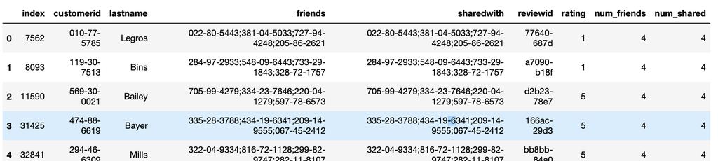

### Suggestions for Requirement 7:

1. **Filtering Reviews**: Start by isolating rows where the review has a rating of either 1 or 5 and where a `reviewid` is specified, indicating a reviewed product.
2. **Non-Empty `friends` and `sharedwith`**: Ensure that both the `friends` and `sharedwith` columns are non-empty, as these are critical for assessing influence.
3. **Unique Customer IDs**: Work under the assumption that each `customerid` is unique for the purpose of this analysis, or ignore `customerid`s that occur more than once in the table.
4. **Parsing Semicolon-separated Lists**: Decide whether to parse the semicolon-separated lists in the `friends` and `sharedwith` columns using SQL functions or Pandas methods.
5. **SQL String Functions**: If using SQL, look into functions like `string_to_array` and `array_length` or `cardinality` for splitting strings into arrays and counting elements.
6. **Pandas String Operations**: In Pandas, utilize `str.split(';')` to split the strings and apply `len` to count the elements for both `friends` and `sharedwith`.
7. **Sorting for Influence**: Sort the data based on the influence metrics, prioritizing reviewers with the highest number of shares and friends.

```python
import pandas as pd

sql = """
    SELECT
    customerid,
    firstname,
    lastname,
    reviewid,
    friends,
    cardinality(string_to_array(TRIM(friends), ';')) AS num_friends,
    sharedwith,
    cardinality(string_to_array(TRIM(sharedwith), ';')) AS num_shares,
    rating
FROM transactions_log
WHERE rating IN (1, 5)
  AND reviewid IS NOT NULL
  AND friends IS NOT NULL
  AND sharedwith IS NOT NULL
  AND TRIM(reviewid::text) != ''
  AND TRIM(friends::text) != ''
  AND TRIM(sharedwith::text) != ''
ORDER BY num_shares DESC;
"""

# Load directly into a DataFrame using your active psycopg2 connection ('conn')
df7 = pd.read_sql_query(sql, db_connection)

# Display the table
display(df7)
```

|  | customerid | firstname | lastname | reviewid | friends | num_friends | sharedwith | num_shares | rating |
| --- | --- | --- | --- | --- | --- | --- | --- | --- | --- |
| 0 | 804-08-6925 | Davon | Lemke | 5f89c-9df2 | 312-75-8483;131-94-2547;673-43-3967;353-41-9434 | 4 | 312-75-8483;131-94-2547;673-43-3967;353-41-9434 | 4 | 5 |
| 1 | 232-24-8024 | Felicita | Schroeder | e02c2-9887 | 332-75-8413;604-70-8798;274-94-5147;109-40-7796 | 4 | 332-75-8413;604-70-8798;274-94-5147;109-40-7796 | 4 | 5 |
| 2 | 021-11-5939 | Karlie | Bruen | e12df-25fe | 864-12-5425;256-22-5694;143-50-6795;522-60-4350 | 4 | 864-12-5425;256-22-5694;143-50-6795;522-60-4350 | 4 | 1 |
| 3 | 896-54-7434 | Estefania | Funk | 5a74f-9f9a | 095-20-3281;627-24-7247;701-95-4952;548-22-9769 | 4 | 095-20-3281;627-24-7247;701-95-4952;548-22-9769 | 4 | 1 |
| 4 | 655-62-8982 | Kendall | Moen | 8d8b5-d769 | 726-01-2220;336-03-5323;482-88-4203;300-76-1557 | 4 | 726-01-2220;336-03-5323;482-88-4203;300-76-1557 | 4 | 1 |
| ... | ... | ... | ... | ... | ... | ... | ... | ... | ... |
| 353300 | 476-13-5987 | Brock | Feil | 3784e-a011 | 581-46-7397;800-66-1452 | 2 | 800-66-1452 | 1 | 1 |
| 353301 | 002-96-1986 | Alexanne | Stamm | 8d770-becd | 200-53-0174;290-65-8740 | 2 | 290-65-8740 | 1 | 1 |
| 353302 | 680-87-5644 | Maryse | Simonis | 09634-8bc7 | 413-81-7261 | 1 | 413-81-7261 | 1 | 1 |
| 353303 | 357-20-4385 | Declan | Hahn | 96c8e-87e3 | 421-25-5339;245-45-4935;169-54-7684;085-13-5204 | 4 | 085-13-5204 | 1 | 5 |
| 353304 | 609-60-8838 | Ronaldo | Hodkiewicz | 8cab6-799a | 895-96-0032;699-10-3026 | 2 | 895-96-0032 | 1 | 5 |

353305 rows × 9 columns

### Requirement 8:

- OnMart has allocated the budget for the next quarter to expand its logistics and supply network by adding a new warehouse in the region that has the highest number of sale orders. Inspect the map below for the list of regions of United States and find the region that has the highest number of orders based on the delivery zip code and the zip code of the distribution center **( Use Python - SQL - Postgres )**
- Your choice to either report based on the four regions shown - West, Midwest, Northeast and South **OR** you can report more granular using the sub-divisions (example: Pacific, Mountain, West North Central, et).

Source: https://upload.wikimedia.org/wikipedia/commons/f/f1/Census_Regions_and_Division_of_the_United_States.svg

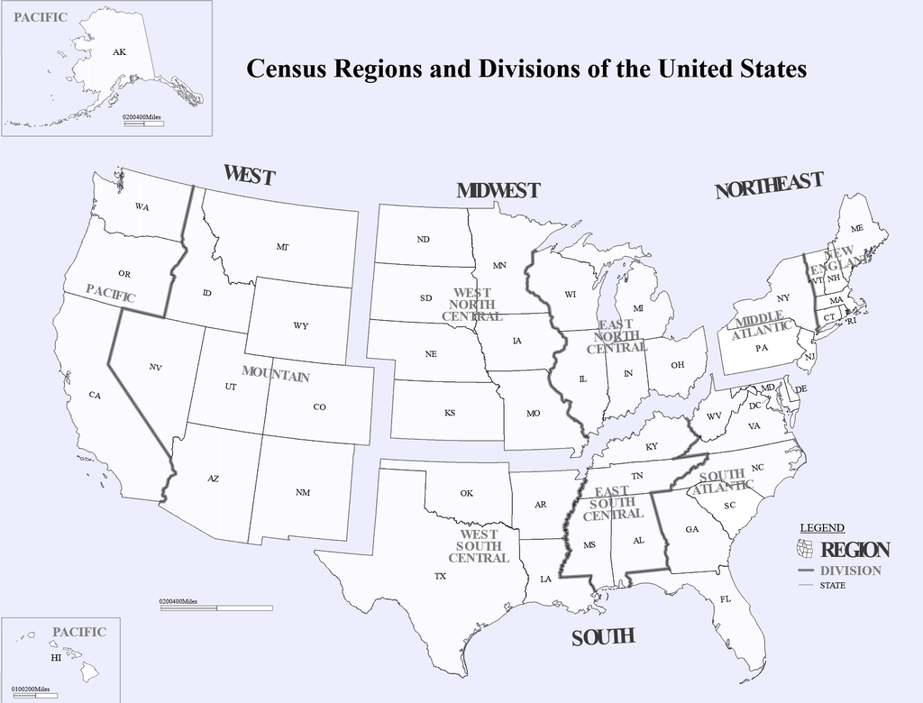

```python
import pandas as pd

sql = """
WITH OrderRegions AS (
    SELECT
        t.orderid,
        t.deliveryzipcode,
        l.distribution_center_id,
        -- Extract the 3-digit zip code prefix and map to the 9 Census Divisions
        CASE
            -- New England: CT, ME, MA, NH, RI, VT
            WHEN LEFT(LPAD(t.deliveryzipcode::text, 5, '0'), 3) BETWEEN '010' AND '069' THEN 'New England'

            -- Middle Atlantic: NJ, NY, PA
            WHEN LEFT(LPAD(t.deliveryzipcode::text, 5, '0'), 3) BETWEEN '070' AND '196' THEN 'Middle Atlantic'

            -- South Atlantic: DE, DC, FL, GA, MD, NC, SC, VA, WV
            WHEN LEFT(LPAD(t.deliveryzipcode::text, 5, '0'), 3) BETWEEN '197' AND '349' THEN 'South Atlantic'

            -- East South Central: AL, KY, MS, TN
            WHEN LEFT(LPAD(t.deliveryzipcode::text, 5, '0'), 3) BETWEEN '350' AND '427' THEN 'East South Central'

            -- East North Central: IL, IN, MI, OH, WI
            WHEN LEFT(LPAD(t.deliveryzipcode::text, 5, '0'), 3) BETWEEN '430' AND '499'
              OR LEFT(LPAD(t.deliveryzipcode::text, 5, '0'), 3) BETWEEN '530' AND '549'
              OR LEFT(LPAD(t.deliveryzipcode::text, 5, '0'), 3) BETWEEN '600' AND '629' THEN 'East North Central'

            -- West North Central: IA, KS, MN, MO, NE, ND, SD
            WHEN LEFT(LPAD(t.deliveryzipcode::text, 5, '0'), 3) BETWEEN '500' AND '528'
              OR LEFT(LPAD(t.deliveryzipcode::text, 5, '0'), 3) BETWEEN '550' AND '588'
              OR LEFT(LPAD(t.deliveryzipcode::text, 5, '0'), 3) BETWEEN '630' AND '693' THEN 'West North Central'

            -- West South Central: AR, LA, OK, TX
            WHEN LEFT(LPAD(t.deliveryzipcode::text, 5, '0'), 3) BETWEEN '700' AND '799' THEN 'West South Central'

            -- Mountain: AZ, CO, ID, MT, NV, NM, UT, WY
            WHEN LEFT(LPAD(t.deliveryzipcode::text, 5, '0'), 3) BETWEEN '800' AND '898' THEN 'Mountain'

            -- Pacific: AK, CA, HI, OR, WA
            WHEN LEFT(LPAD(t.deliveryzipcode::text, 5, '0'), 3) BETWEEN '900' AND '999' THEN 'Pacific'

            ELSE 'Unknown Region'
        END AS region
    FROM transactions_log t
    INNER JOIN logistics_supply_chain_network l
        ON LPAD(t.deliveryzipcode::text, 5, '0') = LPAD(l.zipcode::text, 5, '0')
)
SELECT
    region,
    COUNT(DISTINCT orderid) AS total_orders
FROM OrderRegions
WHERE region != 'Unknown Region'
GROUP BY region
ORDER BY total_orders DESC
LIMIT 1;
"""

# Load directly into a DataFrame using your active psycopg2 connection ('conn')
df8 = pd.read_sql_query(sql, db_connection)

# Display the table
display(df8)
```

|  | region | total_orders |
| --- | --- | --- |
| 0 | South Atlantic | 806618 |

### Requirement 9:

- To better plan for hiring hourly temporary workers on the peak day of the week (Monday, Tuesday, Wednesday, Thursday, Friday, Satruday or Sunday), OnMart has requested to identify the day with the highest average number of order deliveries in every zip-code **( Use Python - SQL - Postgres )**

```python
import pandas as pd

sql = """
    WITH DailyDeliveries AS (
    SELECT
        deliveryzipcode,
        TO_CHAR(actualdeliverydate::date, 'Day') AS day_of_week,
        COUNT(DISTINCT orderid) AS total_deliveries
    FROM transactions_log
    WHERE deliveryzipcode IS NOT NULL
      AND actualdeliverydate IS NOT NULL
    GROUP BY
        deliveryzipcode,
        TO_CHAR(actualdeliverydate::date, 'Day')
),
AverageDeliveries AS (
    SELECT
        deliveryzipcode,
        TRIM(day_of_week) AS peak_delivery_day,
        AVG(total_deliveries) AS avg_deliveries,
        DENSE_RANK() OVER (
            PARTITION BY deliveryzipcode
            ORDER BY AVG(total_deliveries) DESC
        ) AS rank
    FROM DailyDeliveries
    GROUP BY deliveryzipcode, TRIM(day_of_week)
)
SELECT
    deliveryzipcode,
    peak_delivery_day,
    ROUND(avg_deliveries::numeric, 2) AS max_avg_deliveries
FROM AverageDeliveries
WHERE rank = 1
ORDER BY deliveryzipcode;
"""

# Load directly into a DataFrame using your active psycopg2 connection ('conn')
df9 = pd.read_sql_query(sql, db_connection)

# Display the table
display(df9)
```

|  | deliveryzipcode | peak_delivery_day | max_avg_deliveries |
| --- | --- | --- | --- |
| 0 | 10001 | Friday | 653.0 |
| 1 | 10002 | Friday | 706.0 |
| 2 | 10003 | Friday | 705.0 |
| 3 | 10004 | Friday | 612.0 |
| 4 | 10005 | Friday | 662.0 |
| ... | ... | ... | ... |
| 786 | 90103 | Friday | 620.0 |
| 787 | 90174 | Friday | 660.0 |
| 788 | 90185 | Friday | 657.0 |
| 789 | 90774 | Friday | 645.0 |
| 790 | 91671 | Friday | 626.0 |

791 rows × 3 columns